# Intro to Microbial Communities

Kendra Maas

December 17, 2018

# Why are we here?

- Microbes control everything!^*
- We can!
- ^* Well almost, sort of

[figure not shown]

Sequencing Costs by year

# Community profile

- Conserved gene
  - Balance homology and variability

[figure not shown]

# Community profile

- Conserved gene
  - Balance homology and variability

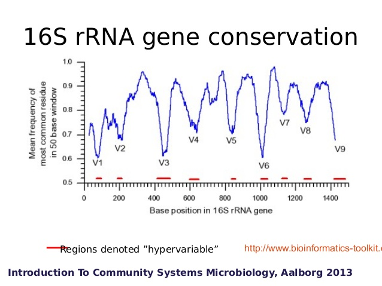

# Cartoon of wet lab process

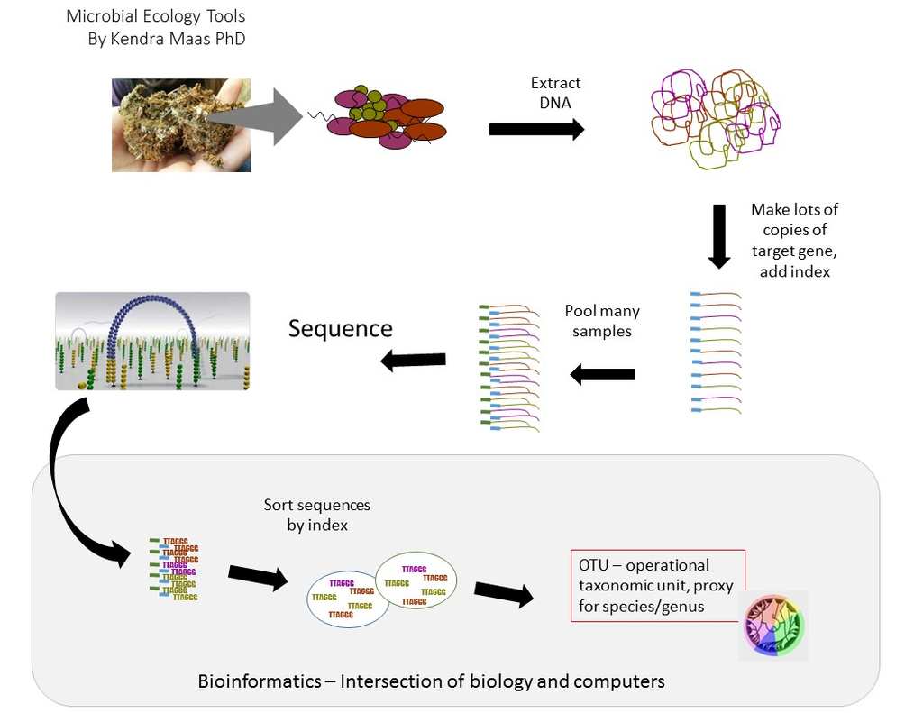

wetlab

# Species?

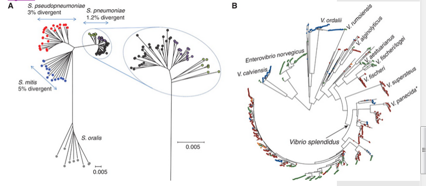

Identify species present

Christophe Fraser,Eric J. Alm, Martin F. Polz, Brian G. Spratt, William P. Hanage Science 6 February 2009: Vol. 323 no. 5915 pp. 741-746 DOI: 10.1126/science.1159388

# Why are we here?

- What to do with MB-GB of sequencing data?
  - Great there are programs!
  - Oh they’re only command line
- How to make sense of complex communities?
  - Multivariate
  - Non-linear
  - Non-normal
  - Independent variables?

# Why are we here?

- Command line
  - Learning curve
  - Customization
  - Learning curve
- **Reproducible Research**

# Reproducible Research

- Document process so it can be replicated
- Enable collaborative analysis
- Reduce time repeating analyses
- Your most important collaborator is yourself 3 months ago and that collaborator doesn’t answer emails.

# Cautionary tale

[figure not shown]

ebola1

# Cautionary tale

[figure not shown]

ebola2

# Cautionary tale

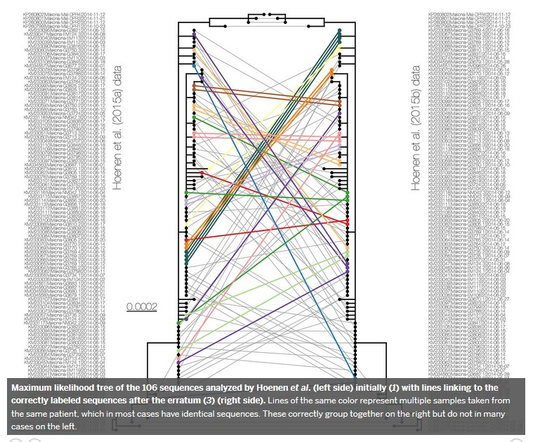

ebola3

Etherpad for this workshop  
https://public.etherpad-mozilla.org/p/mars2018microbiome

Data for the course  
https://drive.google.com/open?id=1CWSTfQaMILXsp7WFqAKAzvPDWzcTh6ee

mothur

Detailed, well documented guide for mothur  
http://www.mothur.org/wiki/MiSeq_SOP

Download the RDP trainset and the Silva db

My scripts for working with sequence data  
https://github.com/krmaas/bioinformatics/

dada2

Good guide for dada2 using the mothur SOP dataset  
https://benjjneb.github.io/dada2/tutorial.html

Basespace

Download all samples in Workshop project

Seqs are barcode names, folder is client name  
I have a one-liner to deal with that but first

bash terminal

| Command | Action |
| --- | --- |
| cd | change directory |
| mv | move (mv -r move folder) |
| ls (-lh) | list files (list details) |
| less | print to screen |
| ctl-shift-c | copy |
| ctl-shift-v | paste |

bash tools

| Tool | function |
| --- | --- |
| sed | find and replace |
| awk | text manipulator |
| vim | text editor |

prep seqs for mothur

Make files file

sample path/to/R1.fastq path/to/R2.fastq

make.file()

Reduce PCR and seqeuencing errors

| Command | Purpose | Finer Points |
| --- | --- | --- |
| make.contigs() | Overlap forward and reverse read | Similar to Pandaseq, q score difference not cutoff |
| summary.seqs() | Check length distribution |  |
| screen.seqs(maxambig, maxlength) | Remove ambiguous bases, too short/long seqs | We remove any seq with any N, length trim *could* have phylogenetic bias |

Housekeeping

| Command | Purpose | Finer Points |
| --- | --- | --- |
| unique.seqs() | Reduces computation cost | count replicats but remove from fasta |
| count.seqs() | Reduces computation cost | replaces names and groups |
| summmary.seqs() |  |  |
| pcr.seqs() | create database w/ just v4 | only need to do once per target |
| system(mv) | call bash commands within mothur |  |
| summary.seqs() | check seqs in silva alignment |  |

Continue cleaning seqs

| Command | Purpose | Finer Points |
| --- | --- | --- |
| align.seqs() | Align to reference | Any alignment is acceptable |
| summary.seqs() |  |  |
| screen.seqs(start, end, maxhomop) | remove seqs misaligned, homopolymers | Further cleaning PCR/sequencing errors using secondary structure |
| filter.seqs(vertical) | remove columns that are all gaps | trump-T removes columns if any gap |
| summary.seqs() |  |  |

Chimera checking

| Command | Purpose | Finer Points |
| --- | --- | --- |
| pre.cluster(diffs) | cluster at 1% differences to reduce computation cost | greedy clustering, balance reducing data w/maintaining diversity |
| summary.seqs() |  | Check change in unique sequences |
| chimera.uchime(dereplicate) | de novo find chimera within each sample | dereplicate, remove chimera from all samples? |
| remove.seqs() |  | defaults remove all flagged seqs |
| summary.seqs() |  |  |

OTU clustering

| Command | Purpose | Finer Points |
| --- | --- | --- |
| classify.seqs(reference, taxonomy) |  | default Wang/RDP |
| remove.lineage(taxon) | remove wetlab bycatch | Chloroplast-Mitochondria-unknown-Archaea-Eukaryota |
| summary.tax() |  | file for Krona plots |
| cluster.split(splitmethod, taxlevel, cutoff) | heuristic cluster within taxon | limiting by classification reduces computation without greedy |
| make.shared(label) | create OTU table | uneven seqs/sample |

Alpha and Beta diversity

| Command | Purpose | Finer Points |
| --- | --- | --- |
| count.groups() |  | determine subsample level |
| summary.single(calc, subsample) | alpha diversity |  |
| dist.shared(calc, subsample, iters) | beta diversity | reduce iters if in a hurry |
| classify.otu() | attach names to OTUs | Doesn’t impact clustering |
| get.oturep(method) | abudance or centroid |  |
| sub.sample(shared, size) |  | For feature selection |